# Visualizing spatial data: tmap and chloropeths

This post describes oil spill occurrence throughout California in 2008. Data is from the CA DFW Oil Spill Incident Tracking database.

Nicole Schmidt true  
02-25-2021

```r
knitr::opts_chunk$set(echo = FALSE, warning = FALSE, message = FALSE)

# load libraries
library(tidyverse)
library(here)
library(sf)
library(janitor)
library(tmap)
library(gstat)
library(stars)
library(lubridate)
library(ggsn)
library(ggspatial)

# read in data and do some wrangling

oil_spill <- read_sf(here("Oil_Spill_Incident_Tracking_%5Bds394%5D-shp", "Oil_Spill_Incident_Tracking_%5Bds394%5D.shp")) %>%
  clean_names()

#summary(oil_spill)

#oil_spill %>% st_crs() #check the CRS; WGS 84 3857

ca_counties <- read_sf(here("ca_counties", "CA_Counties_TIGER2016.shp")) %>%
  clean_names() %>%
  rename(county_name = name, land_area = aland)

#ca_counties %>% st_crs() # the same CRS as oil spill data  (WGS 84 3847)
```

#### Introduction

This project looks at oil spill occurrence and counts by county throughout California. The Office of Spill Prevention and Response (OSPR) Incident Tracking Database is responsible for tracking oil spills throughout the state. Oil spill presence data is collected by the OSPR Field and Response Team for oil spill in marine waters and the OSPR Inland Pollution Coordinators and Wardens for inland oil spills.

#### Count of inland oil spill events by California counties for 2008 oil spills

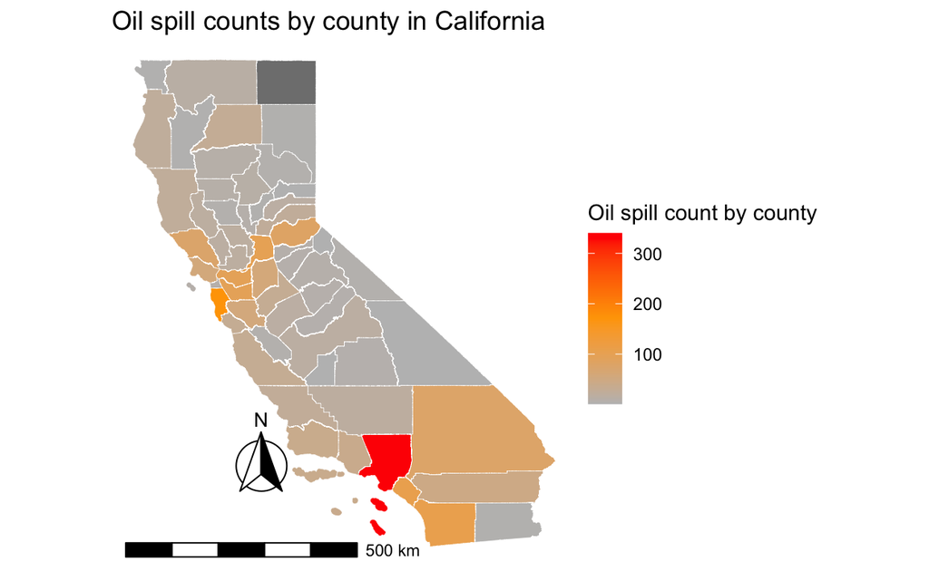

```r
# wrangle data to get counts of inland oil spill events by county for 2008 oil spill

oil_spill_count <- oil_spill %>%
  mutate(date = lubridate::ymd(dateofinci)) %>%
  filter(inlandmari == "Inland") %>%
  count(localecoun)

#Join data frames together to plot
oil_spill_join <- ca_counties %>%
  st_join(oil_spill_count)

# plot oil spills within the county
ggplot(data = oil_spill_join) +
  geom_sf(aes(fill = n), color = "white", size = 0.1) +
  scale_fill_gradientn(colors = c("grey","orange","red")) +
  theme_void() +
  labs(fill = "Oil spill count by county", title = "Oil spill counts by county in California")+
  annotation_scale(location = "bl", width_hint = .5)+
  annotation_north_arrow(location = "bl", which_north = "true", pad_x = unit(.75, "in"), pad_y = unit(.5, "in"), style = north_arrow_fancy_orienteering())
```

**Figure 2:** Map of the occurrence of inland oil spills by California County. The highest occurrence of oil spills in 2008 occurred in Los Angeles County. There is no data for Modoc County, which is displayed in dark gray. Data Source: CA DFW Oil Spill Incident Tracking

#### Conclusion

- Oil spills that occurred throughout California in 2008 occurred mostly in marine and freshwater locations
- In 2008 the top 5 California Counties that experienced the most *inland* oil spills were: Los Angeles, San Mateo, Alameda, San Diego, and Orange Counties.

#### Data Source:

CA DFW Oil Spill Incident Tracking